# 4th Semester Result Analysis

Piyush Jain

2025-05-20

## R Markdown

Hello to anyone, who is reading this. My name is Piyush Jain, and this is my analysis of my class results for the 4th Semester. I have acquired my data and have properly arranged it in a way that anyone who read this will understand it.  
And if you are interested to check last semesters result analysis,

## 2nd Semester Results

## 3rd Semester Results

#### Click Here

In the following table, if any of my friends are reading this they can see there results in the bottom table.

|  | student.name | hall_ticket_number | MS | FFM | RM | SPM | WT | English | Extra.Curricular.Activities | Certificate.course | MOOCS | SGPA | Final_Result |
| --- | --- | --- | --- | --- | --- | --- | --- | --- | --- | --- | --- | --- | --- |
| 1 | SARDARNI GURUPREET KAUR | 121423408001 | O | O | A+ | O | O | O | O | O | A | 9.81 | PASS |
| 2 | SHLESHA SHARMA | 121423408002 | O | O | O | O | A+ | A+ | O | A | A | 9.74 | PASS |
| 3 | VEERAMALLY SAIKRISHNA | 121423408003 | A | A+ | A | A | B+ | A | A+ | B+ | B+ | 8 | PASS |
| 4 | RAJVEER CHARAN | 121423408004 | B+ | A | D | A | B | A | A+ | A+ | A | 6.7 | PASS |
| 5 | MAYANK GUPTA | 121423408005 | A | A | A | A | B+ | A | O | O | B+ | 7.81 | PASS |
| 6 | PIYUSH JAIN | 121423408006 | A+ | A+ | A+ | O | A+ | A+ | O | A | A | 9.19 | PASS |
| 7 | K VYSHNAVI | 121423408008 | A+ | O | A+ | A+ | A+ | A | O | A+ | A | 9.11 | PASS |
| 8 | MOHAMMED MUDDASIR MOHIUDDIN | 121423408009 | C | F | A | F | B | B+ | A | B | B+ | 6.33 | COMPLETED |
| 9 | ROHITH REDDY VELLANKI | 121423408010 | A | A | A | A | B+ | A | D | A | A | 7.81 | PASS |
| 10 | PARSHAROUTHU SUJITH VERMA | 121423408011 | A | A | A | A | C | A | A+ | A+ | A | 7.44 | PASS |

[output cut: 48 more lines]

## Plots of BBA IT Sem 4 Results

In the multiple plots that we have been given below we clearly see the number of students that have passed or failed in the subjects:

Management Science, Fundamentals of Financial Management, Research Methodology, Web Technologies, Software Project Management, English for Employability

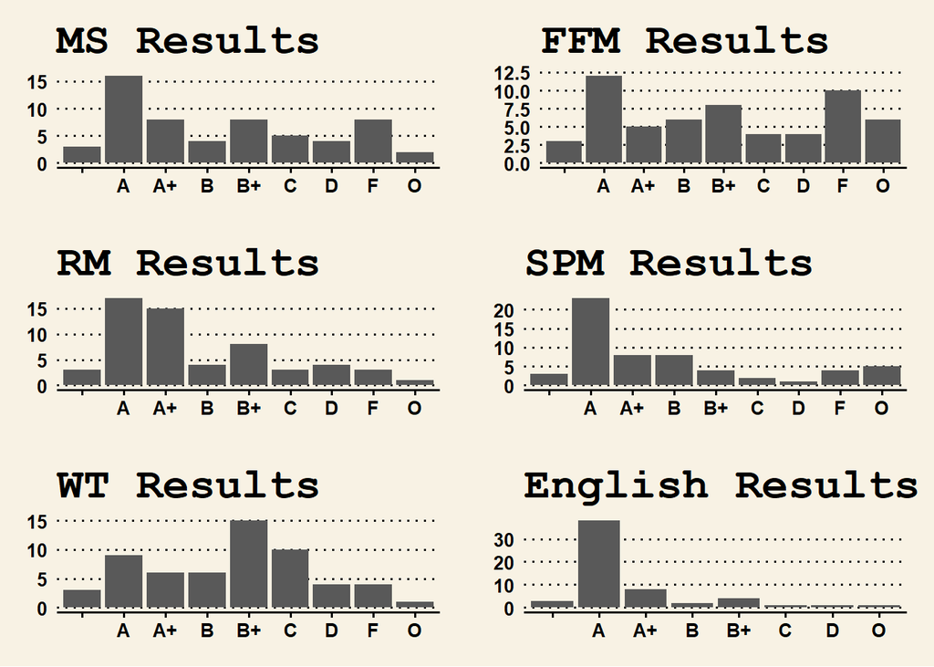

## RM Plot

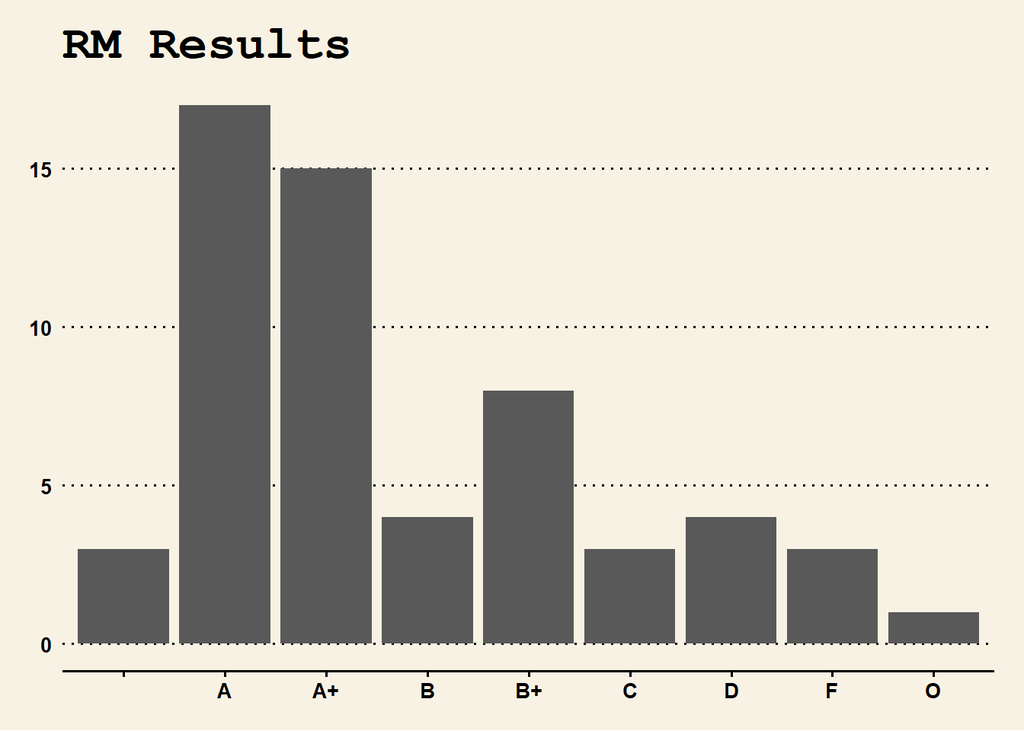

## FFM Plot

Oh ho, FFM man only 16 % students failed, i lost my money god damn. and This Subject has the most students scoring O’s. I guess I am a really good motivator

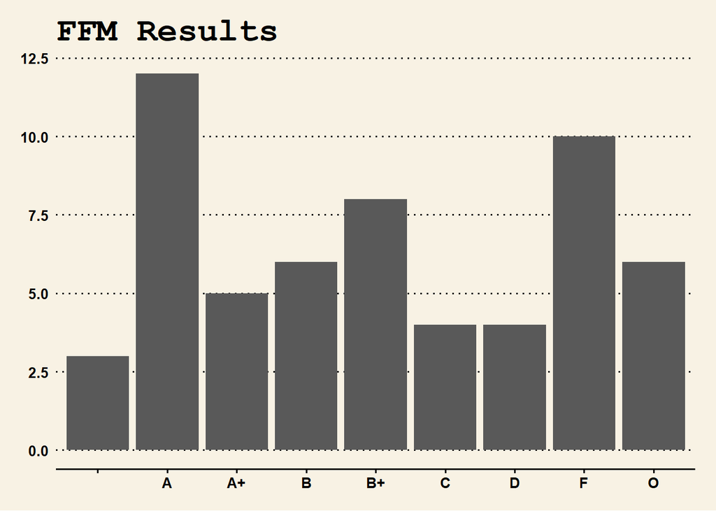

## MS Plot

I hope this maam does not come next semester, I dont want to hear her grandfather’s death, The score of MS is distributed fairly equally.

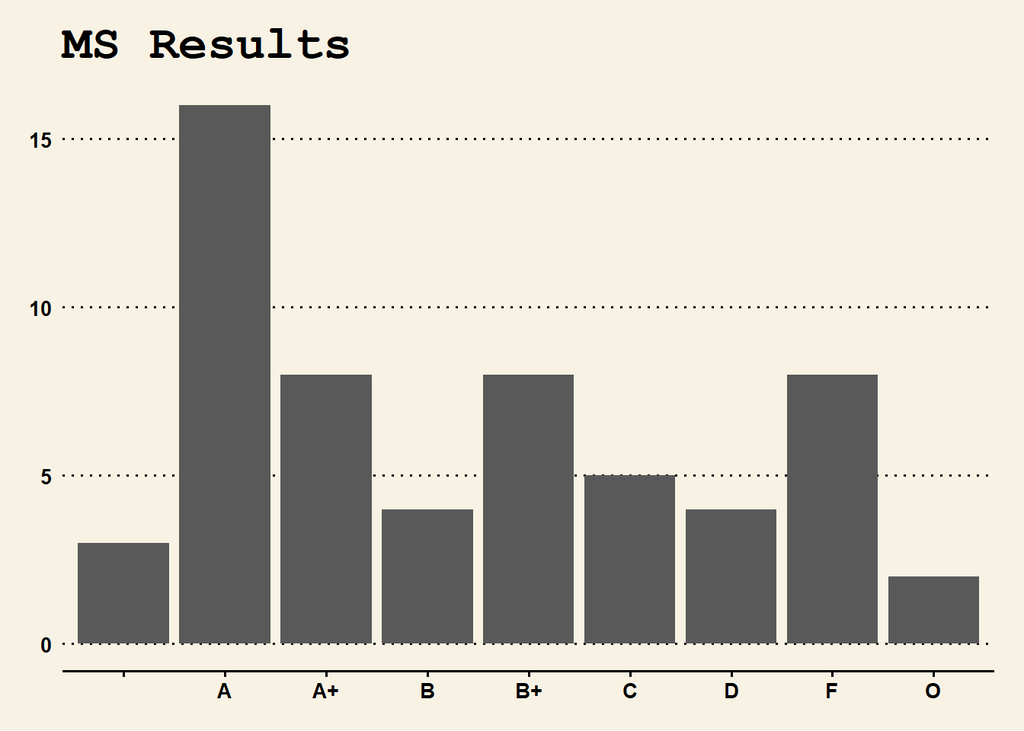

## Web Technologies Result

Web Technologies, Very less failures this time.

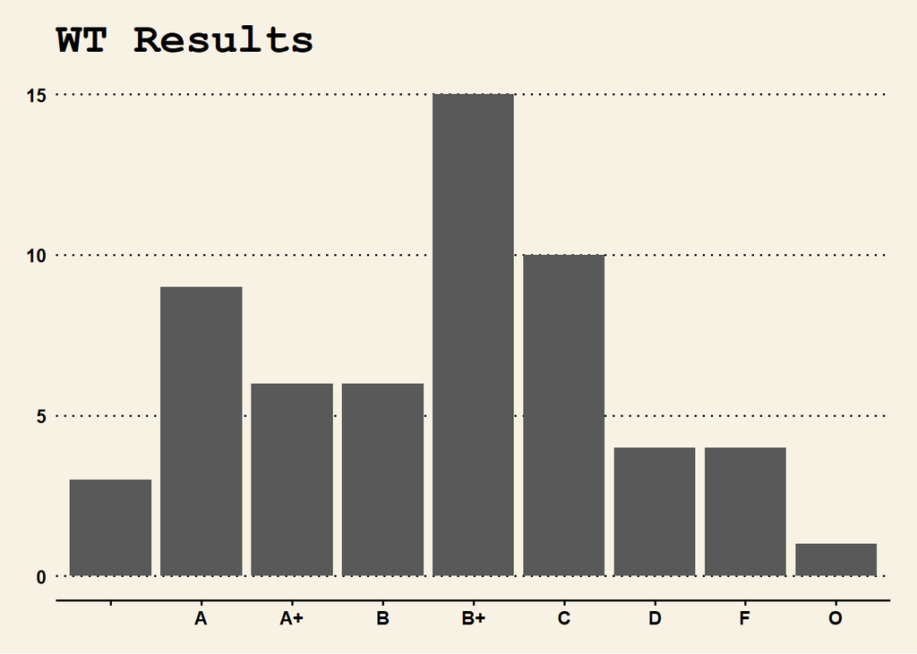

## SPM Plot

Most of them scored really well for this exam.

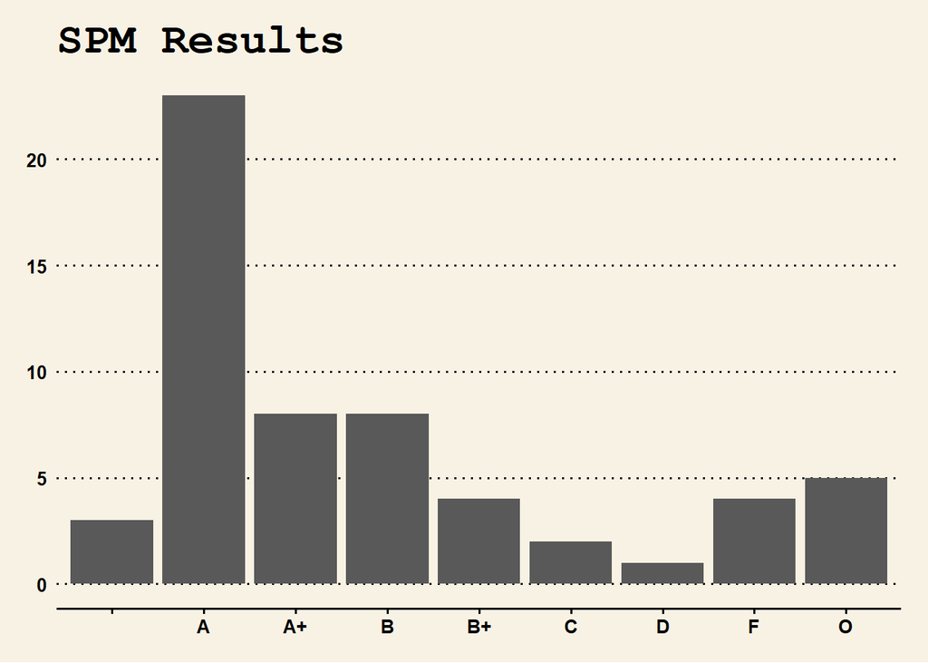

This was the most easiest subject out of all subjects and we can clearly see in the graph that majority of students have scored excellent grades.

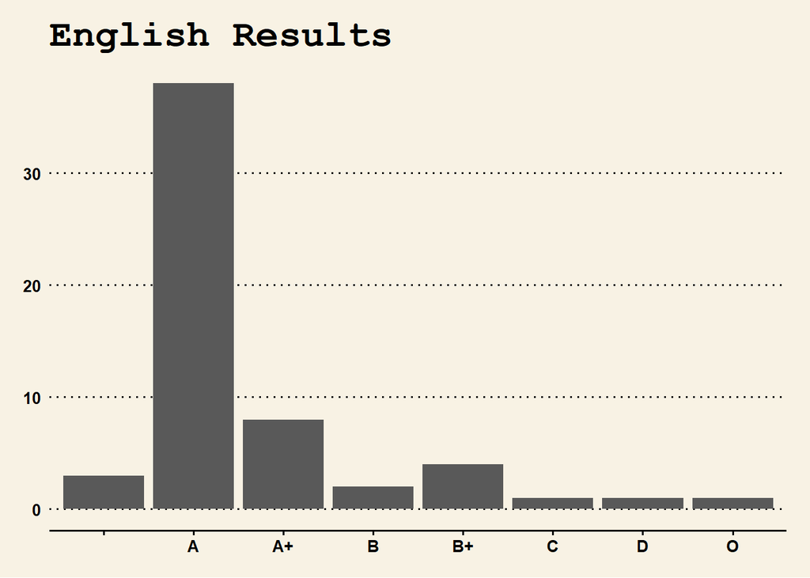

## Top 10 performing students

This semester the top 10 students performed are given below in the table where most of the students had a tough time, these students passed with an exceptional grade. This time Gurpreet has scored the best marks.

| student.name | hall_ticket_number | MS | FFM | RM | SPM | WT | English | Extra.Curricular.Activities | Certificate.course | MOOCS | SGPA | Final_Result |
| --- | --- | --- | --- | --- | --- | --- | --- | --- | --- | --- | --- | --- |
| SARDARNI GURUPREET KAUR | 121423408001 | O | O | A+ | O | O | O | O | O | A | 9.81 | PASS |
| SHLESHA SHARMA | 121423408002 | O | O | O | O | A+ | A+ | O | A | A | 9.74 | PASS |
| KOTA GIRI VARSHA | 121423408026 | A+ | O | A+ | O | A+ | A+ | O | A+ | A | 9.37 | PASS |
| DOSANI RAHIM | 121423408029 | A+ | O | A+ | O | A+ | A+ | O | A | A | 9.37 | PASS |
| PIYUSH JAIN | 121423408006 | A+ | A+ | A+ | O | A+ | A+ | O | A | A | 9.19 | PASS |
| K VYSHNAVI | 121423408008 | A+ | O | A+ | A+ | A+ | A | O | A+ | A | 9.11 | PASS |
| RETIWALE NEHA SINGH | 121423408012 | A+ | O | A+ | A+ | A+ | A | O | A | A | 9.11 | PASS |
| MARYAM BAIG | 121423408041 | A | A+ | A+ | A+ | A | A+ | O | A+ | A | 8.63 | PASS |
| SYED AASIA AFSHEEN | 121423408017 | A+ | A | A+ | A+ | A | A | O | A+ | A | 8.56 | PASS |
| DASHRATH DINESH SAI SACHIN | 121423408039 | A | A+ | A+ | A+ | A | A | O | O | A | 8.56 | PASS |